# Which chemcial property is related to white wine quality? by Zi Ye

This is a dataset of white wine variants of the Portuguese “Vinho Verde” wine.

# Univariate Plots Section

A summary of this dataset including mean, median, and quantiles:

```
##  fixed.acidity    volatile.acidity  citric.acid     residual.sugar
##  Min.   : 3.800   Min.   :0.0800   Min.   :0.0000   Min.   : 0.600
##  1st Qu.: 6.300   1st Qu.:0.2100   1st Qu.:0.2700   1st Qu.: 1.700
##  Median : 6.800   Median :0.2600   Median :0.3200   Median : 5.200
##  Mean   : 6.855   Mean   :0.2782   Mean   :0.3342   Mean   : 6.391
##  3rd Qu.: 7.300   3rd Qu.:0.3200   3rd Qu.:0.3900   3rd Qu.: 9.900
##  Max.   :14.200   Max.   :1.1000   Max.   :1.6600   Max.   :65.800
##    chlorides       free.sulfur.dioxide total.sulfur.dioxide
##  Min.   :0.00900   Min.   :  2.00      Min.   :  9.0
##  1st Qu.:0.03600   1st Qu.: 23.00      1st Qu.:108.0
##  Median :0.04300   Median : 34.00      Median :134.0
##  Mean   :0.04577   Mean   : 35.31      Mean   :138.4
##  3rd Qu.:0.05000   3rd Qu.: 46.00      3rd Qu.:167.0
##  Max.   :0.34600   Max.   :289.00      Max.   :440.0
##     density             pH          sulphates         alcohol
##  Min.   :0.9871   Min.   :2.720   Min.   :0.2200   Min.   : 8.00
##  1st Qu.:0.9917   1st Qu.:3.090   1st Qu.:0.4100   1st Qu.: 9.50
##  Median :0.9937   Median :3.180   Median :0.4700   Median :10.40
##  Mean   :0.9940   Mean   :3.188   Mean   :0.4898   Mean   :10.51
##  3rd Qu.:0.9961   3rd Qu.:3.280   3rd Qu.:0.5500   3rd Qu.:11.40
##  Max.   :1.0390   Max.   :3.820   Max.   :1.0800   Max.   :14.20
##     quality
##  Min.   :3.000
##  1st Qu.:5.000
##  Median :6.000
##  Mean   :5.878
##  3rd Qu.:6.000
##  Max.   :9.000
```

For a better visualization of distributions, each variable is plotted in a histogram:

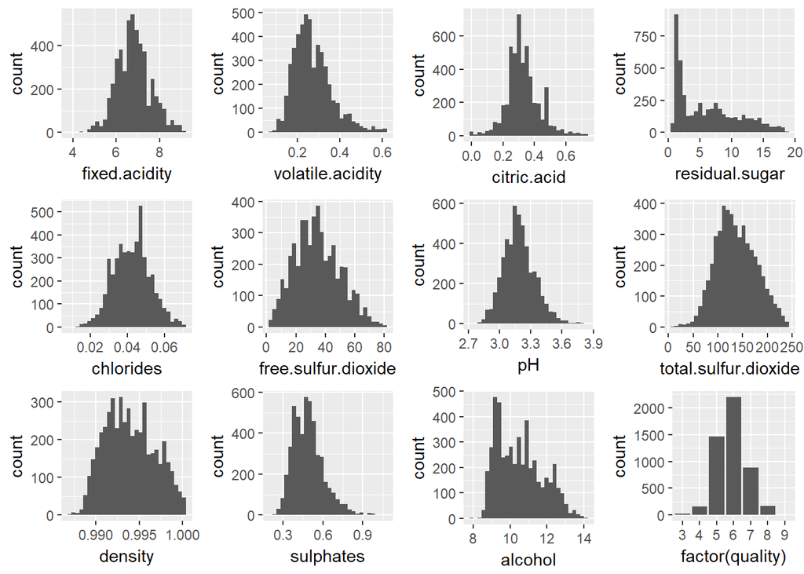

# Univariate Analysis

### The structure:

This dataset contains 12 variables (including 11 chemical properties and the median quality evaluated by 3 experts) of 4898 white wine samples.

### The main feature that I am interested:

The most interesting feature is the quality of wines. I am interested in how chemical properties of white relate to their taste (quality). Acoording to the features of variables, acidity, sulfur dioxide, alcohol, and sugar content might have impact on taste and quality.

### The adjustment I did:

I created a new variable called quality.factor by transforming the quality variable to factors since the quality score is discrete and each score is a evaluation category. I also noticed that the fixed acidity and volatile acidity can be combined into a total.acidity variable to simplify the analysis.

```r
wine = transform(wine, total.acidity = fixed.acidity + volatile.acidity)
wine = transform(wine, quality.factor = factor(quality))
```

# Bivariate Plots Section

Here I am interested to investigate which chemical property is related to the wine quality. According to the description of variables, high level of acidity and sulfur dioxide seem to give the wine bad taste, and it is not clear which properties are related to good taste.

A quick way to study the interaction between variables is to simply plot all of them against each other and calculate their correlations:

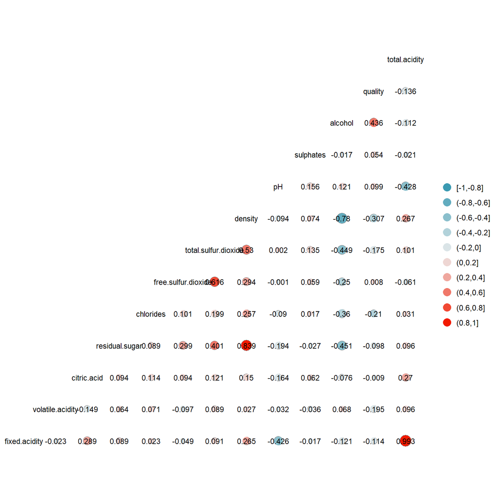

Look like only alcohol content has a moderate correlation (0.436) with quality. Here I plotted alcohol against quality.factor:

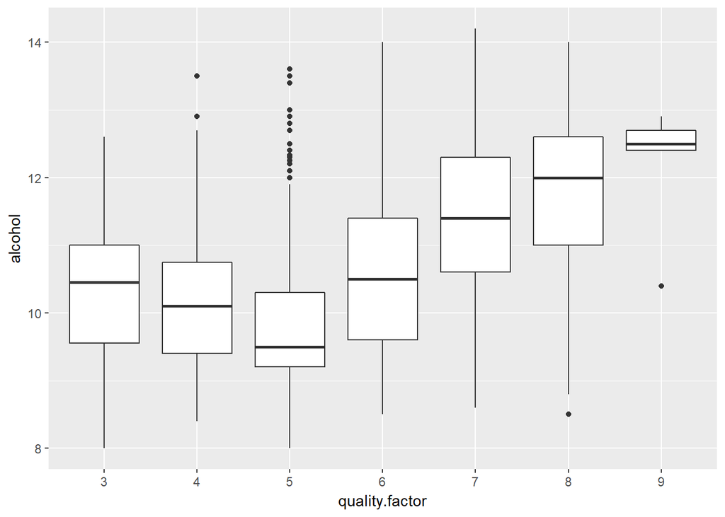

It is quite noticeable that high quality wine also has high alcohol content. Then I plotted total.acidity and total.sulfur.dioxide that are suspected to negatively impact the quality against the quality.factor:

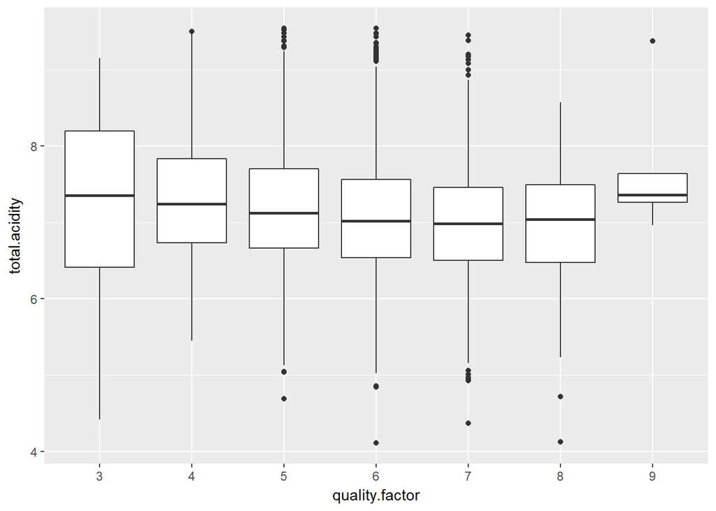

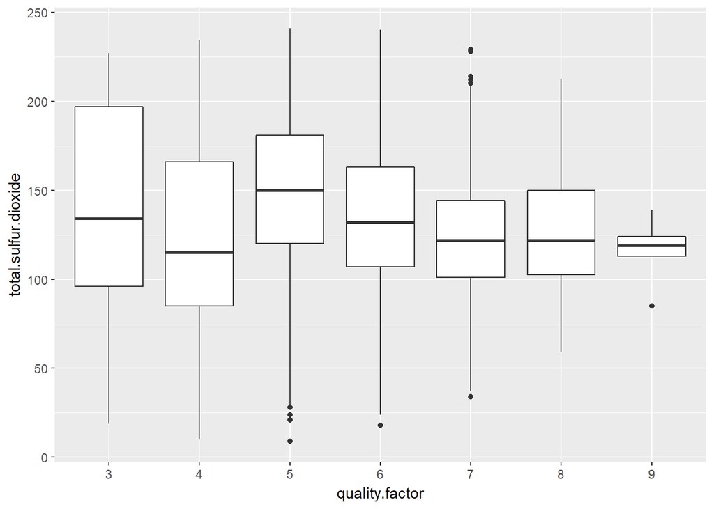

It does not look like acidity and sulfur dioxide impact the quality. Then I plotted sugar which is a testant against quality.factor:

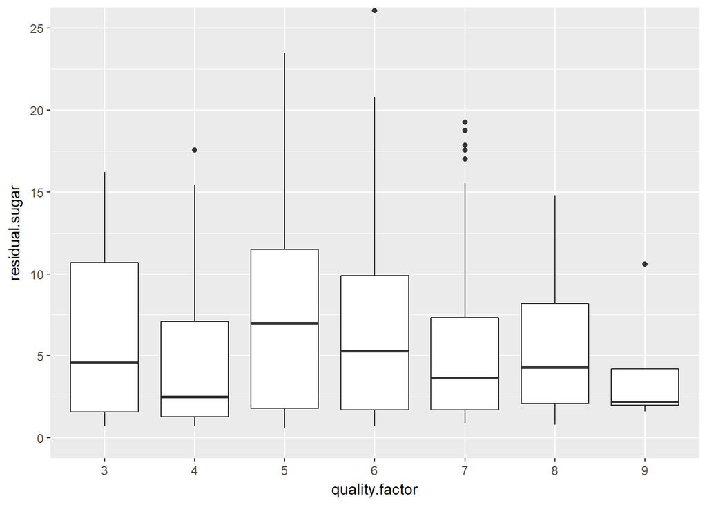

Still, it is not very clear that sugar content impact quality. Since density is related to alcohol and sugar, it is interesting to plot density against quality.factor:

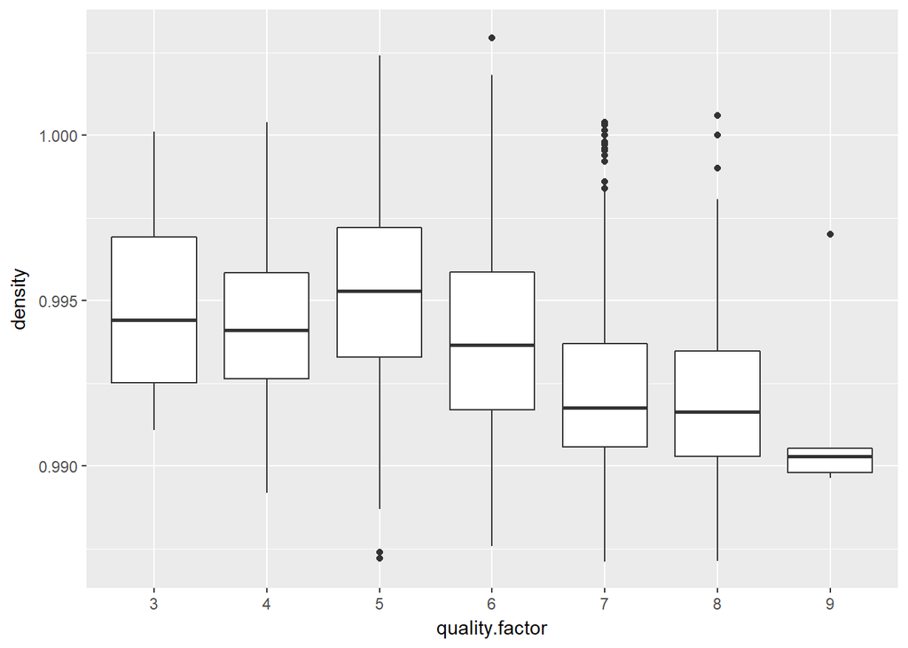

It make sense that density is related to quality since alcohol content directly imapct density.

Some other interesting points are to look at the relationship between pH and acidity:

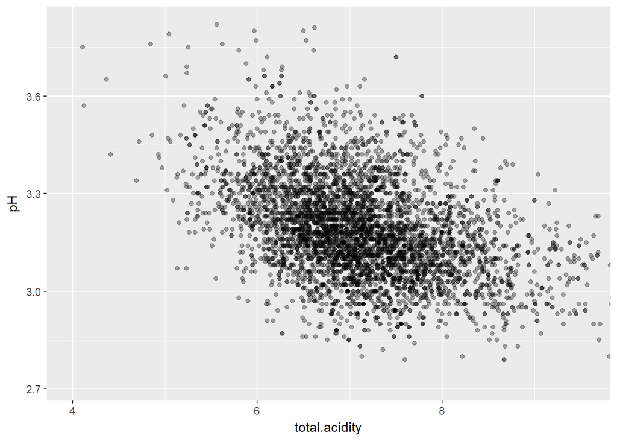

sulphates and sulfur.dioxide:

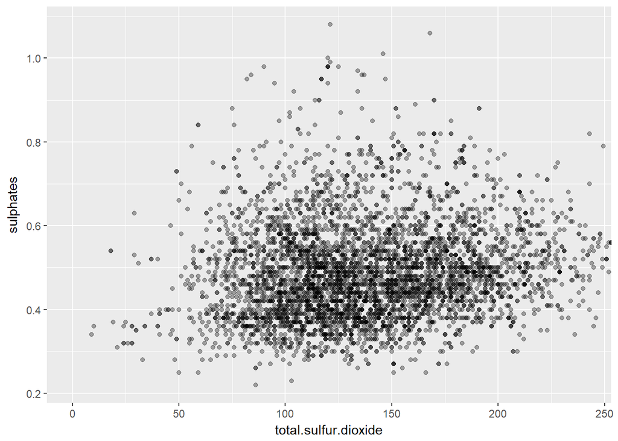

sugar and density:

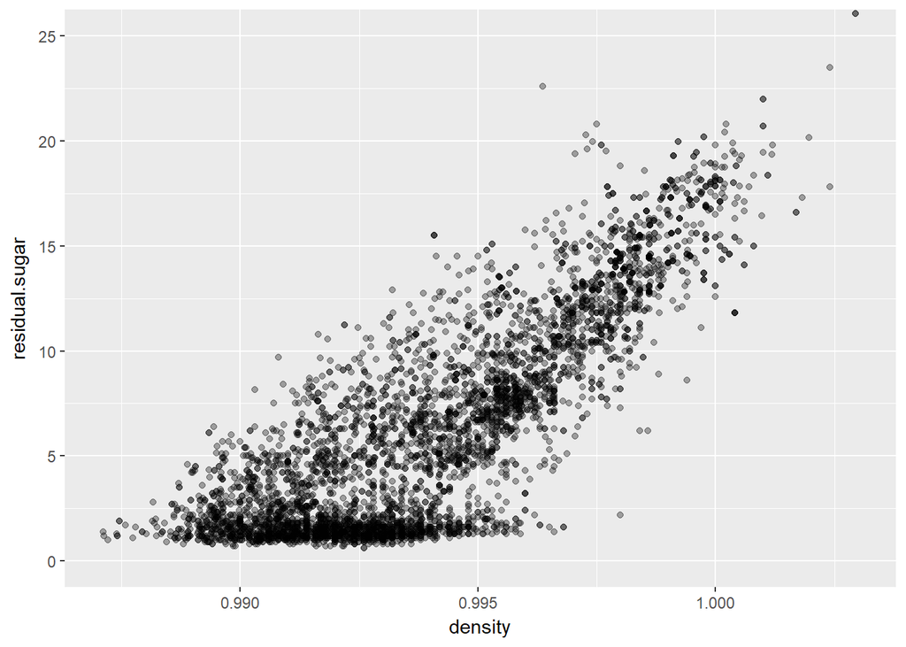

alcohol and density:

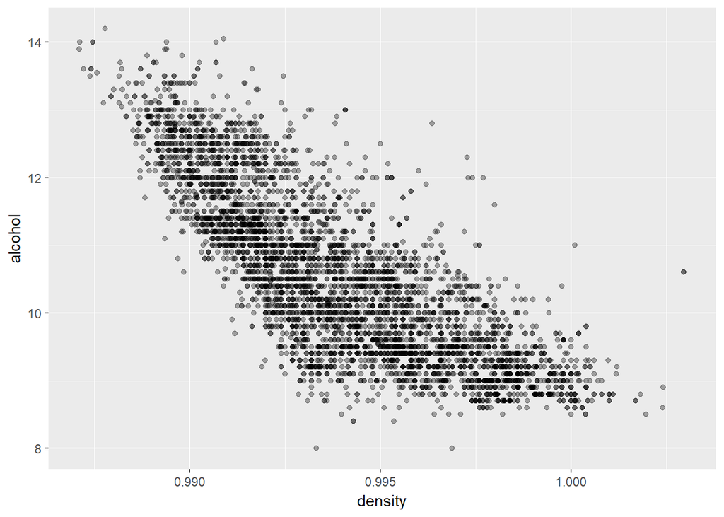

# Bivariate Analysis

### Noticeable relationships:

The most notable relationship is between quality and alcohol content. It seems that high alcohol content is related to high quality, and since density is related to the relative ratio between sugar and alcohol, the higher density the lower the alcohol content and therefore the lower the quality. (It is hard to make high alcohol content wine, since yeasts cannot survive in high alcoholic environment.)

I expected pH and total acidity to have a strong correlation since pH is a indicator of how acidic the wine is. However, even though there is a correlation between acidity and pH but not very strong. The reason of this weak correlation could be the acid in wine are not strong acid that release all of their protons in the solution, which makes sense since wine contains a lot of artaric acid from the grapes.

It is also not suprising that sulphates and total sulfur dioxide is not very strongly correlated since not all of the sulphates can be transform to sulfur dioxide due to the various chemical conditions in different wines.

# Multivariate Plots Section

Now it looks like alcohol content has a moderate positive impact on quality while other features (acidity, sulfur dioxide, sugar, density and citric acid) are included into the plot:

First, I classify sulfur dioxide and acidity for better visualization:

```r
wine$total.sulfur.dioxide.bucket =
  cut(wine$total.sulfur.dioxide, breaks = c(0,100,125,150,175,200,500))
wine$total.acidity.bucket =
  cut(wine$total.acidity, breaks = c(0,6.5,7,7.5,15))
```

Since I want to use scatter plot to visualize the third variable, here I treat quality as a numeric variable instead of factor, and I put quality to y-axis:

quality against alcohol and acidity:

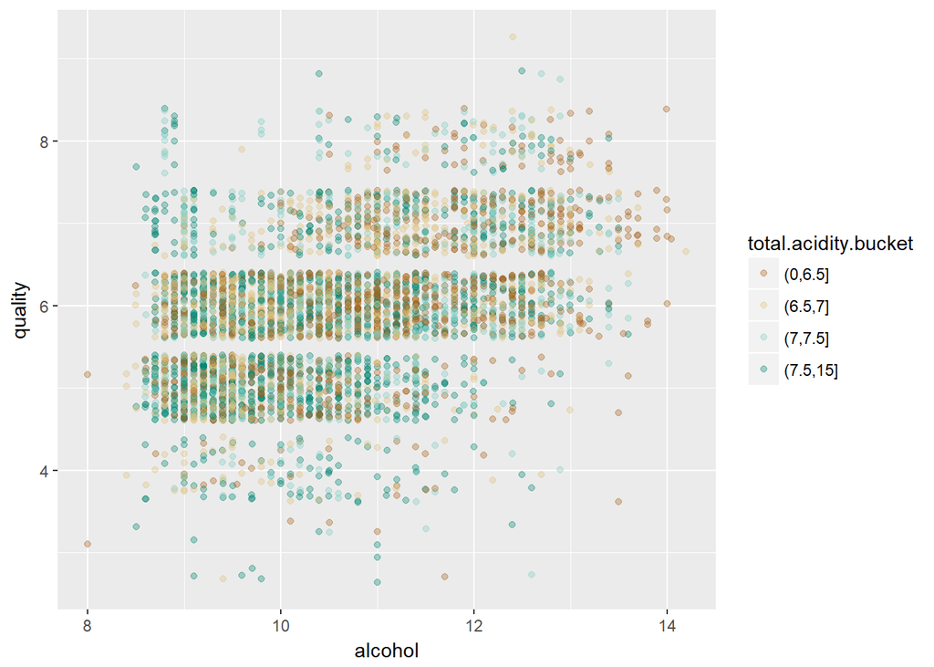

quality against alcohol and sulfur dioxide:

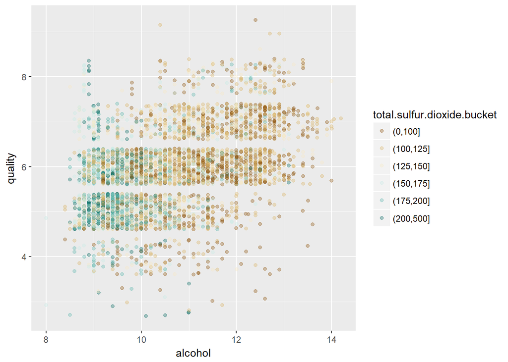

quality against alcohol and sugar:

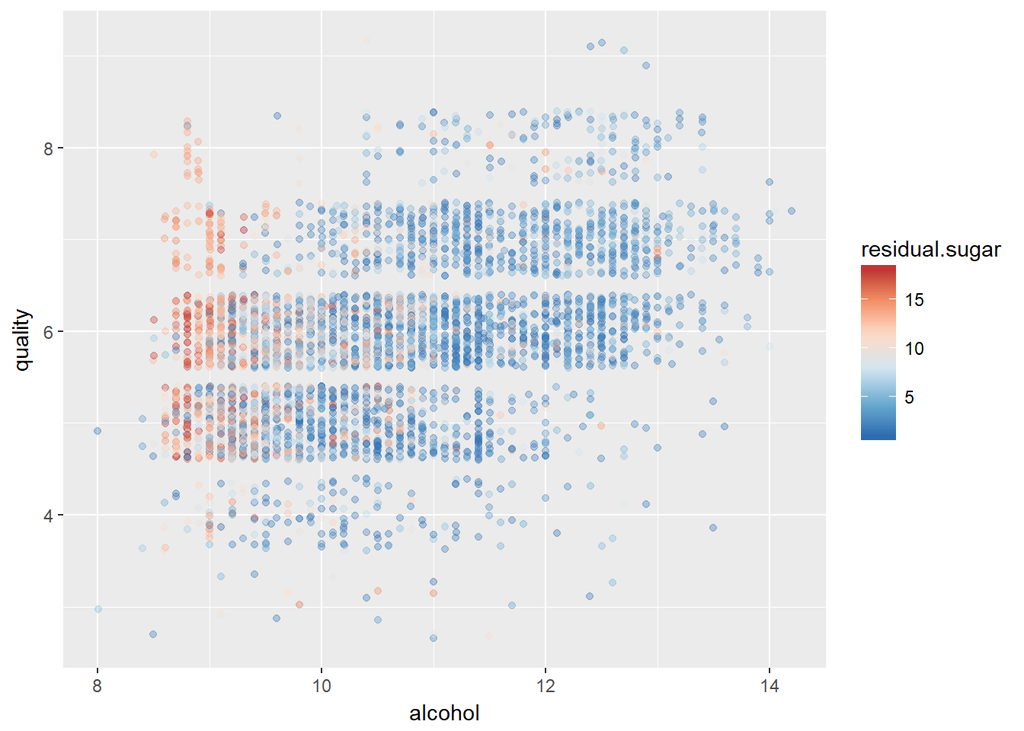

quality against alcohol and density:

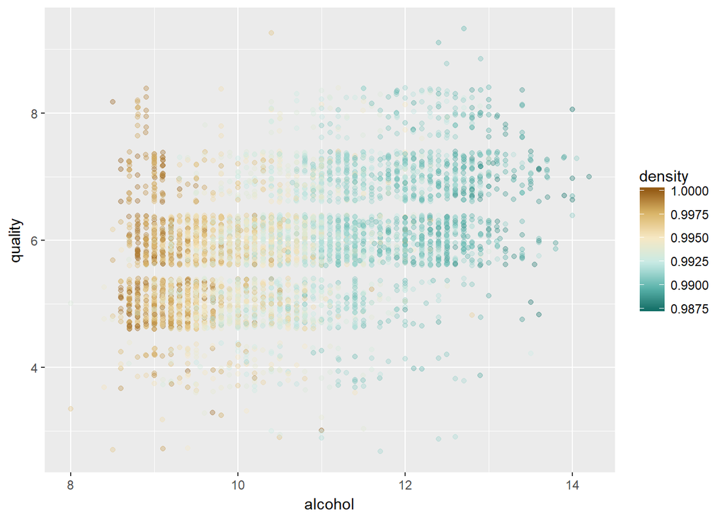

quality against alcohol and citric acid:

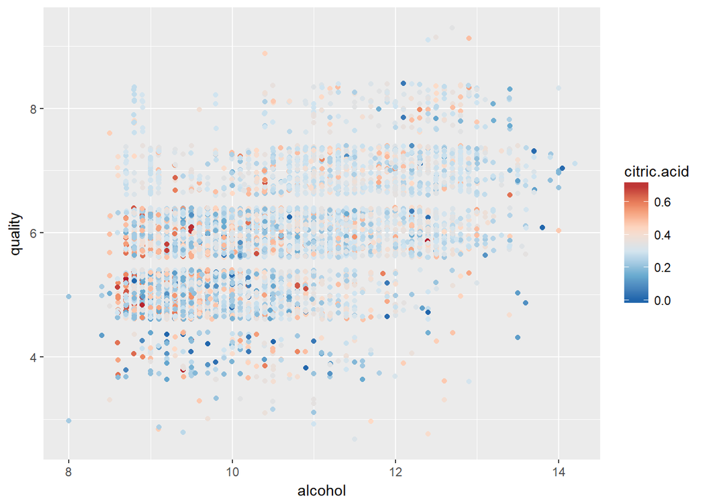

Last, I built a linear model:

```r
summary(lm(quality ~ alcohol + total.acidity + total.sulfur.dioxide +
             residual.sugar + citric.acid, data = wine))
```

```
##
## Call:
## lm(formula = quality ~ alcohol + total.acidity + total.sulfur.dioxide +
##     residual.sugar + citric.acid, data = wine)
##
## Residuals:
##     Min      1Q  Median      3Q     Max
## -3.5763 -0.5393 -0.0056  0.4737  3.2770
##
## Coefficients:
##                        Estimate Std. Error t value Pr(>|t|)
## (Intercept)           2.775e+00  1.705e-01  16.273  < 2e-16 ***
## alcohol               3.474e-01  1.084e-02  32.037  < 2e-16 ***
## total.acidity        -1.108e-01  1.384e-02  -8.000 1.54e-15 ***
## total.sulfur.dioxide -8.072e-05  3.067e-04  -0.263 0.792437
## residual.sugar        2.227e-02  2.566e-03   8.679  < 2e-16 ***
## citric.acid           3.252e-01  9.696e-02   3.354 0.000803 ***
## ---
## Signif. codes:  0 '***' 0.001 '**' 0.01 '*' 0.05 '.' 0.1 ' ' 1
##
## Residual standard error: 0.7863 on 4892 degrees of freedom
## Multiple R-squared:  0.2126, Adjusted R-squared:  0.2118
## F-statistic: 264.1 on 5 and 4892 DF,  p-value: < 2.2e-16
```

# Multivariate Analysis

### Summary:

other than alcohol content, I did not see other noticeable features play an important role in quality. The reason could be all the wine samples have above average quality, and therefore the chemical contents are all in a small range and even the low quality samples in this dataset have decent chemical property.

The problem of my linear model is that the quality is a discrete variable and there is not a very clear linear relationship, and other variables does not have great impact on this model.

# Final Plots and Summary

### Plot One

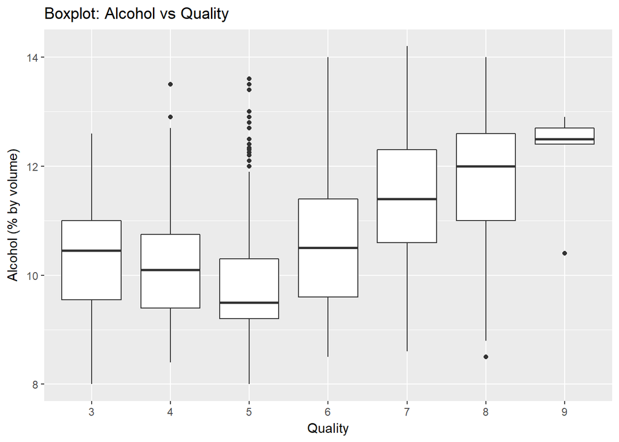

### Description One

This plot shows the relationship between quality and alcohol content where the overall trend is that high quality wines seem to have a relatively high the alcohol content.

### Plot Two

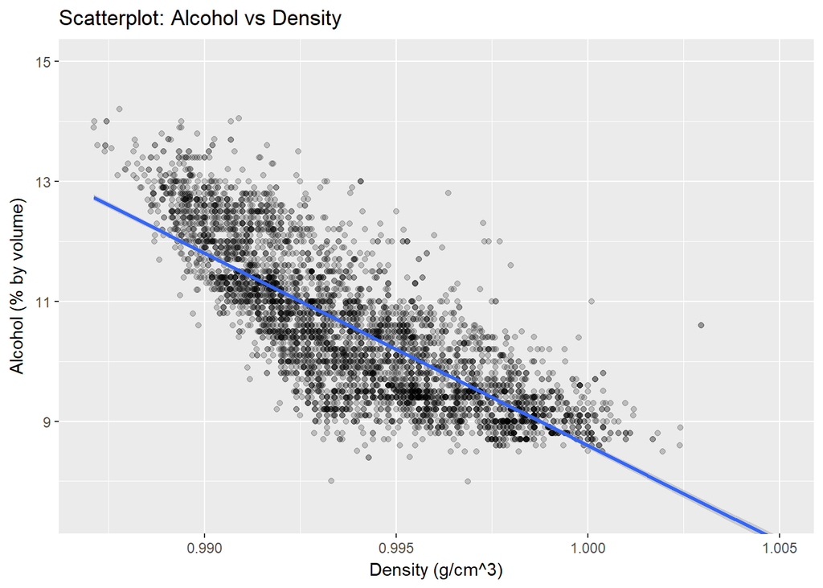

### Description Two

This plot shows the strong correlation between alcohol content and density which interprets the weak correlation between density and quality. Alcohol content is tastable while density is not, and therefore alcohol content is more likely to be the real reason that impacts quality.

### Plot Three

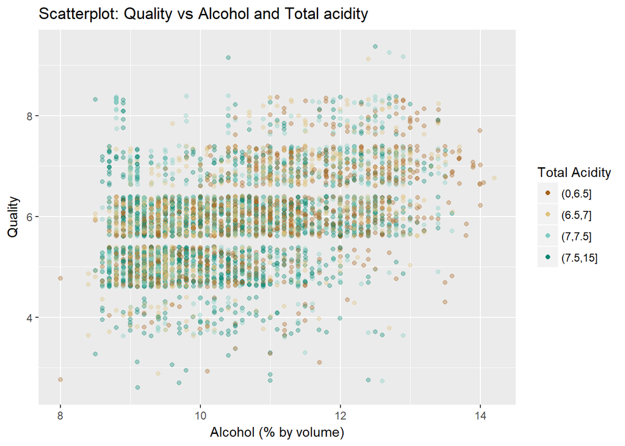

### Description Three

It is surprising that acidity does not have a noticeable impact on quality. Even some of the high quality wines have high acidity.

# Reflection

The struggle is that most of the variables do not have even moderate correlation with the feature that I am interested in (quality). It seems like it is hard to just use these chemical properties to predict wine quality. There might be other chemicals that are more related to wine taste or even some other features of wine have impact on taste.

In the future, this dataset could include more chemical properties and have more precise quality classification. More high quality wines (above 7) and low quality wines (below 5) could also help better distinguish wine quality and build models.